# Reproducible Research: Peer Assessment 1 - Jim Condon

## Lead Libraries

```r
library(tidyr)
library(plyr)
```

```r
library(ggplot2)
library(gridExtra)
library(knitr)
```

## Loading and preprocessing the data

```r
activity_data <- read.csv("activity.csv")
```

## What is mean total number of steps taken per day?

We do a quick analysis of the data by creating a histogram of the steps each day.  
First we aggregate the data by date (removing na), then create the histogram.

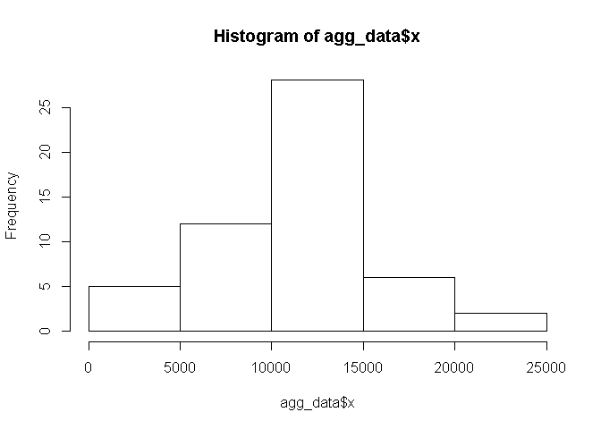

```r
activity_data_without_na <- activity_data[complete.cases(activity_data),]
agg_data <- aggregate(activity_data_without_na$steps, list(date = activity_data_without_na$date), sum)
hist(agg_data$x)
```

Now we calculate the mean and median of the total steps per day.

```r
activity_mean <- mean(agg_data$x)
activity_mean
```

```
## [1] 10766.19
```

```r
activity_median <- median(agg_data$x)
activity_median
```

```
## [1] 10765
```

## What is the average daily activity pattern?

First average (mean) data by interval across all days.

```r
avg_data <- aggregate(activity_data_without_na$steps, list(interval = activity_data_without_na$interval), mean)
```

Then plot the data in a time series.

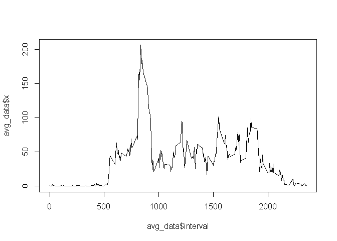

```r
plot(avg_data$interval, avg_data$x, type = "l")
```

```r
max(avg_data$x)
```

```
## [1] 206.1698
```

## Imputing missing values

Calculate the number of rows with NAs.

```r
nrow(activity_data[!complete.cases(activity_data),])
```

```
## [1] 2304
```

Now we replace all the NA values with the mean for that interval. First we create a new data frame with the mean for each interval in a new column.

```r
activity_data_with_avg <- merge(activity_data, avg_data, by = "interval")
```

Then we replace all NA values in steps with the mean for that interval.

```r
activity_data_with_avg[is.na(activity_data_with_avg$steps),]$steps <- activity_data_with_avg[is.na(activity_data_with_avg$steps),]$x
```

Create histogram and calculate mean/median as earlier to compare.

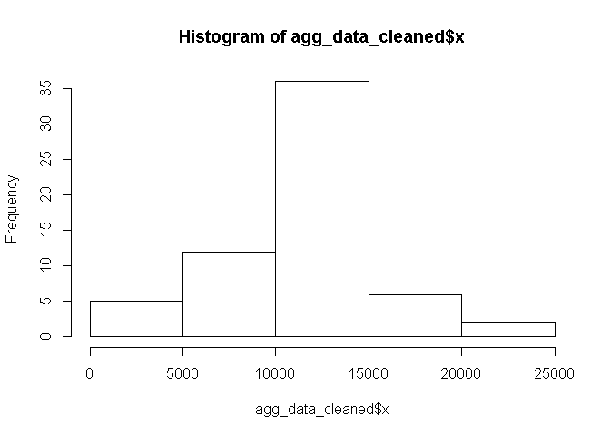

```r
agg_data_cleaned <- aggregate(activity_data_with_avg$steps, list(date = activity_data_with_avg$date), sum)
hist(agg_data_cleaned$x)
```

Now we calculate the mean and median of the total steps per day.

```r
activity_mean <- mean(agg_data_cleaned$x)
activity_mean
```

```
## [1] 10766.19
```

```r
activity_median <- median(agg_data_cleaned$x)
activity_median
```

```
## [1] 10766.19
```

## Are there differences in activity patterns between weekdays and weekends?

## need to create new datasets with replaced NAs based on avg_data then subset for weekday/weekend

We create a new variable called weekday that lists the weekday of the date in our data that has replaced NA values.

```r
activity_data_with_avg$weekday <- weekdays(as.Date(activity_data_with_avg$date))
```

Then we subset our data into 2 separate datasets one for weekends and one for weekdays.

```r
activity_data_with_avg_weekday <- subset(activity_data_with_avg, weekday != "Saturday" & weekday != "Sunday")
```

```r
activity_data_with_avg_weekend <- subset(activity_data_with_avg, weekday == "Saturday" | weekday == "Sunday")
```

Then we aggregate the data by interval.

```r
agg_interval_data_weekday <- aggregate(activity_data_with_avg_weekday$steps, list(interval = activity_data_with_avg_weekday$interval), mean)
```

```r
agg_interval_data_weekend <- aggregate(activity_data_with_avg_weekend$steps, list(interval = activity_data_with_avg_weekend$interval), mean)
```

Now we plot both graphs.

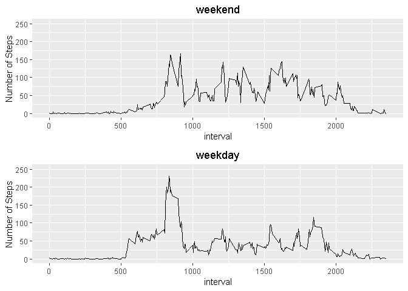

```r
weekend <- ggplot(data = agg_interval_data_weekend, aes(x = interval, y = x)) + geom_line() + ggtitle("weekend") + theme(plot.title = element_text(hjust = 0.5)) + labs(y = "Number of Steps") + ylim(c(0, 250))
weekday <- ggplot(data = agg_interval_data_weekday, aes(x = interval, y = x)) + geom_line() + ggtitle("weekday") + theme(plot.title = element_text(hjust = 0.5)) + labs(y = "Number of Steps") + ylim(c(0, 250))
grid.arrange(arrangeGrob(weekend, weekday, nrow = 2))
```